# Descriptive Statistics

## Density plots

To create a smooth density, we use the `geom_density`. To make a smooth density plot with the data previously shown as a histogram we can use this code:

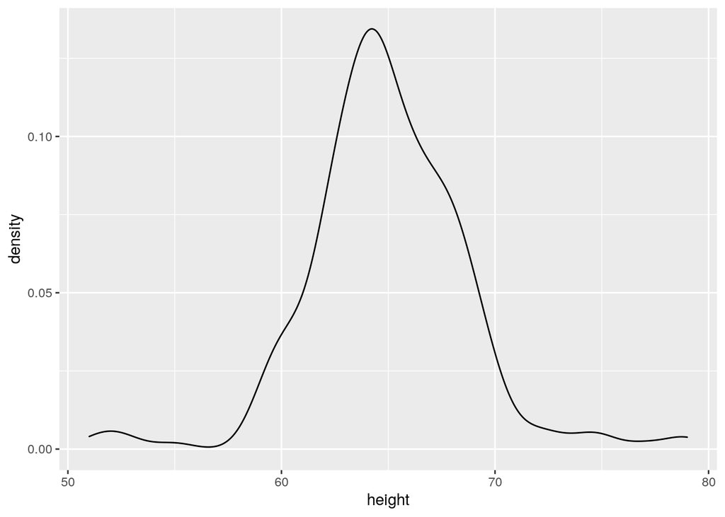

```r
heights %>%
  filter(sex == "Female") %>%
  ggplot(aes(height)) +
  geom_density()
```

To fill in with color, we can use the `fill` argument.

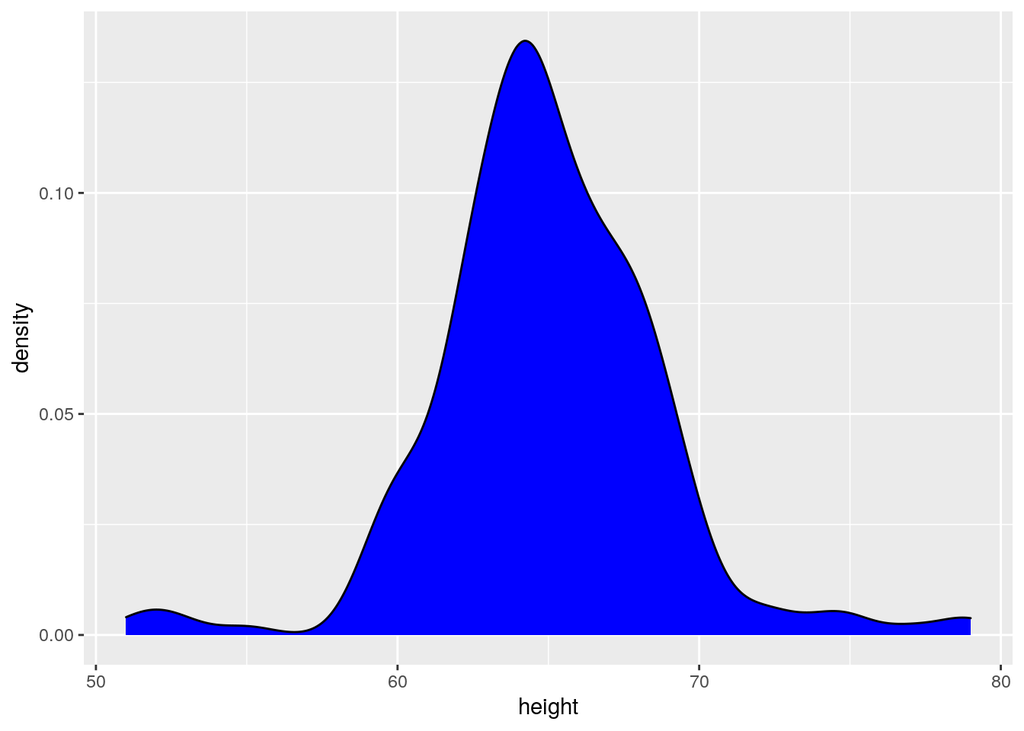

```r
heights %>%
  filter(sex == "Female") %>%
  ggplot(aes(height)) +
  geom_density(fill="blue")
```

To change the smoothness of the density, we use the `adjust` argument to multiply the default value by that `adjust`. For example, if we want the bandwidth to be twice as big we use:

```r
heights %>%
  filter(sex == "Female") +
  geom_density(fill="blue", adjust = 2)
```

[output not shown]

## Boxplots

The geometry for boxplot is `geom_boxplot`. Boxplots are useful for comparing distributions. For example, below are the previously shown heights for women, but compared to men. For this geometry, we need arguments `x` as the categories, and `y` as the values.

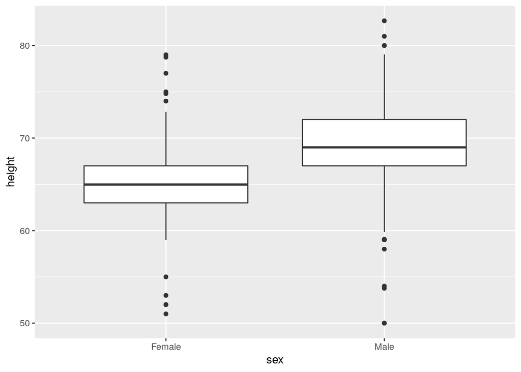

```r
heights %>% ggplot(aes(sex, height)) +
  geom_boxplot()
```

## QQ-plots

For qq-plots we use the `geom_qq` geometry. Here is the qqplot for men heights. We need to standardise the data first using scale and then make a qqplot against the standard normal.

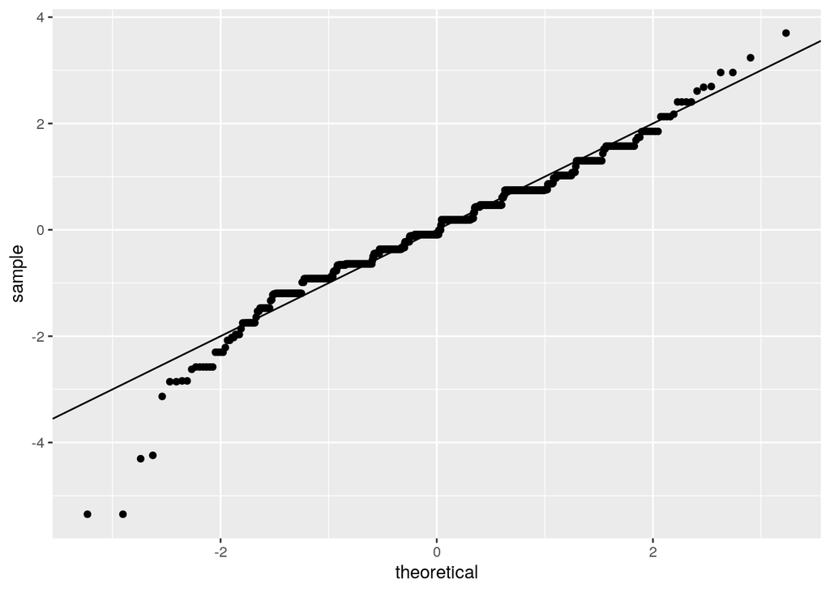

```r
heights %>%
  filter(sex=="Male") %>%
  ggplot(aes(sample = scale(height))) +
  geom_qq() +
  geom_abline()
```

# ASSOCIATIONS

Relatively simple **ggplot2** code can create insightful plots.

We will be using the `gapminder` dataset provided in **dslabs**.

```r
data(gapminder)
gapminder %>% as_tibble()
```

```
## # A tibble: 10,545 x 9
##    country  year infant_mortality life_expectancy fertility population      gdp
##    <fct>   <int>            <dbl>           <dbl>     <dbl>      <dbl>    <dbl>
##  1 Albania  1960            115.             62.9      6.19    1636054 NA
##  2 Algeria  1960            148.             47.5      7.65   11124892  1.38e10
##  3 Angola   1960            208              36.0      7.32    5270844 NA
##  4 Antigu…  1960             NA              63.0      4.43      54681 NA
##  5 Argent…  1960             59.9            65.4      3.11   20619075  1.08e11
##  6 Armenia  1960             NA              66.9      4.55    1867396 NA
##  7 Aruba    1960             NA              65.7      4.82      54208 NA
##  8 Austra…  1960             20.3            70.9      3.45   10292328  9.67e10
##  9 Austria  1960             37.3            68.8      2.7     7065525  5.24e10
## 10 Azerba…  1960             NA              61.3      5.57    3897889 NA
## # … with 10,535 more rows, and 2 more variables: continent <fct>, region <fct>
```

## Bar plots

Which country do you think had the highest child mortality rates in 2015? Sri Lanka or Turkey?

```r
gapminder %>%
  filter(year == 2015 & country %in% c("Sri Lanka","Turkey")) %>%
  select(country, infant_mortality)
```

```
##     country infant_mortality
## 1 Sri Lanka              8.4
## 2    Turkey             11.6
```

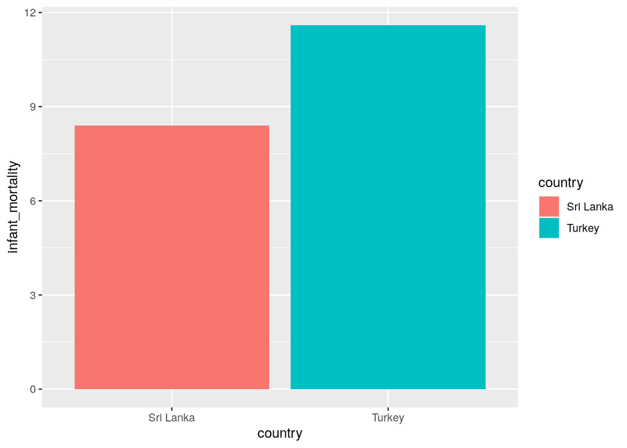

```r
gapminder %>%
  filter(year == 2015 & country %in% c("Sri Lanka","Turkey")) %>%
  select(country, infant_mortality) %>%
  ggplot(aes(country,infant_mortality,fill=country)) +
  geom_bar(stat="identity")
```

Turkey has the higher infant mortality rate.

## Scatterplots

Investigate the life expectancy versus fertility rates (average number of children per woman) in 1962.

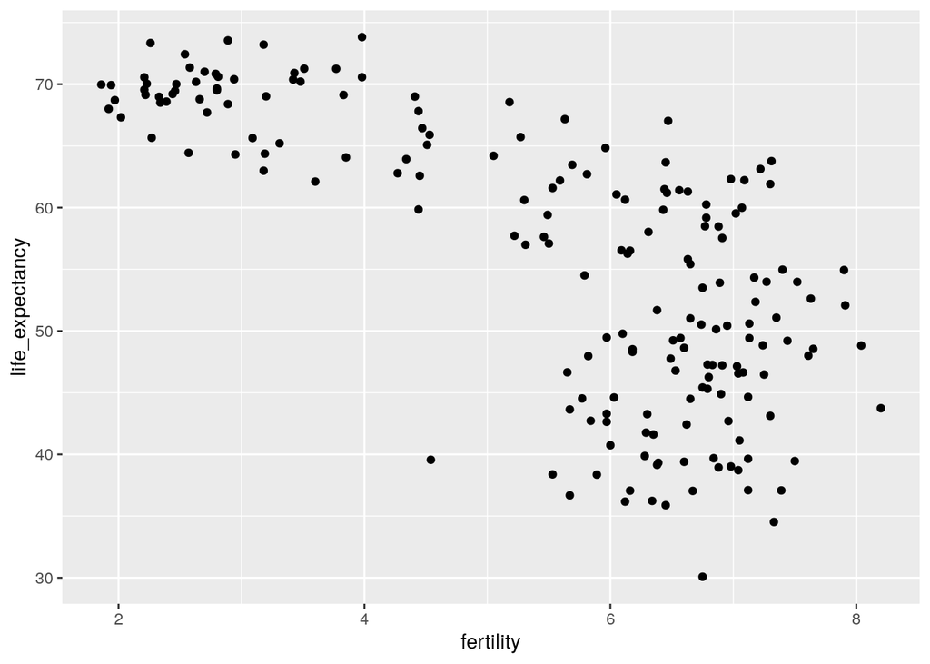

```r
filter(gapminder, year == 1962) %>%
  ggplot(aes(fertility, life_expectancy)) +
  geom_point()
```

Most points fall into two distinct categories:

1. Life expectancy around 70 years and 3 or fewer children per family.
2. Life expectancy lower than 65 years and more than 5 children per family.

To confirm that indeed these countries are from the regions we expect, we can use color to represent continent.

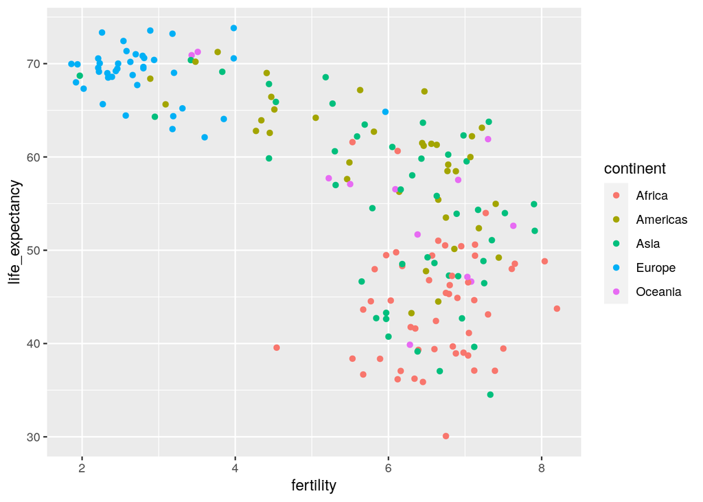

```r
filter(gapminder, year == 1962) %>%
  ggplot( aes(fertility, life_expectancy, color = continent)) +
  geom_point()
```

## Faceting

We could easily plot the 2012 data in the same way we did for 1962. To make comparisons, however, side by side plots are preferable. In **ggplot2**, we can achieve this by *faceting* variables:

We add a layer with the function `facet_grid`, which automatically separates the plots.

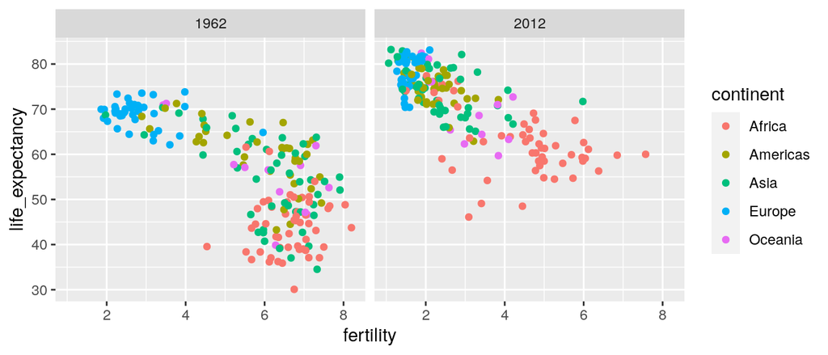

```r
filter(gapminder, year%in%c(1962, 2012)) %>%
  ggplot(aes(fertility, life_expectancy, col = continent)) +
  geom_point() +
  facet_grid(. ~ year)
```

This plot clearly shows that the majority of countries have moved from the *developing world* cluster to the *western world* one. In 2012, the western versus developing world view no longer makes sense. This is particularly clear when comparing Europe to Asia, the latter of which includes several countries that have made great improvements.

## Data transformations

The `gapminder` data table includes a column with the countries’ gross domestic product (GDP). GDP measures the market value of goods and services produced by a country in a year. The GDP per person is often used as a rough summary of a country’s wealth. Here we divide this quantity by 365 to obtain the more interpretable measure *dollars per day*.

```r
gapminder <- gapminder %>%  mutate(dollars_per_day = gdp/population/365)
```

### Log transformation

Here is a histogram of per day incomes from 1970:

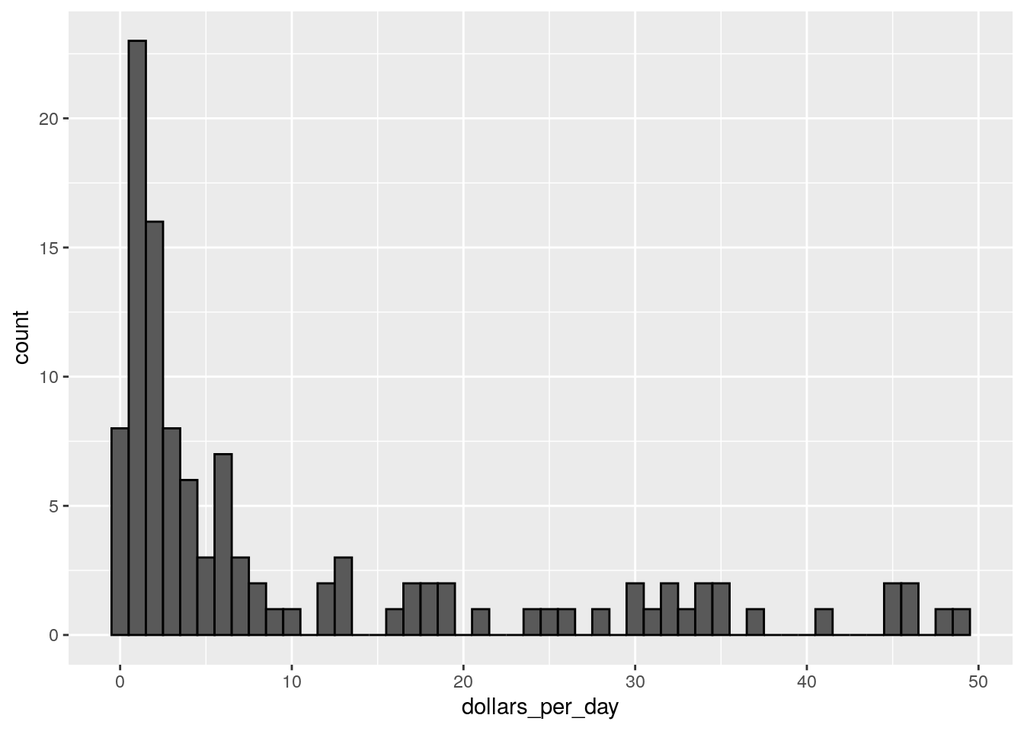

```r
gapminder %>%
  filter(year == 1970 & !is.na(gdp)) %>%
  ggplot(aes(dollars_per_day)) +
  geom_histogram(binwidth = 1, color = "black")
```

In this plot, we see that for the majority of countries, averages are below $10 a day. The plot is not very informative about countries with values below $10 a day.

It might be more informative to quickly be able to see how many countries have average daily incomes of about $1 (extremely poor), $2 (very poor), $4 (poor), $8 (middle), $16 (well off), $32 (rich), $64 (very rich) per day. These changes are multiplicative and log transformations convert multiplicative changes into additive ones: when using base 2, a doubling of a value turns into an increase by 1.

Here is the distribution if we apply a log base 2 transform:

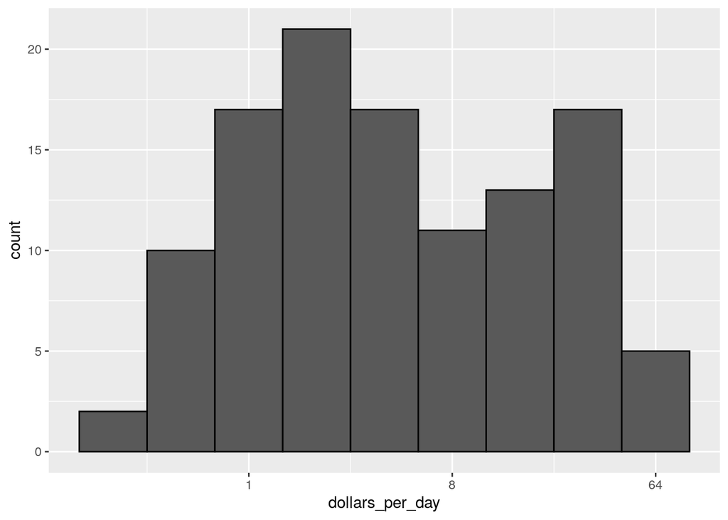

```r
gapminder %>%
  filter(year == 1970 & !is.na(gdp)) %>%
  ggplot(aes(dollars_per_day)) +
    scale_x_continuous(trans = "log2") +
  geom_histogram(binwidth = 1, color = "black")
```

In a way this provides a *close-up* of the mid to lower income countries.

## Comparing multiple distributions with boxplots and ridge plots

In this section we demonstrate how to visualize and compare distributions across groups.

### Boxplots

Look at GDP between 1970 and 2010 over all continents.

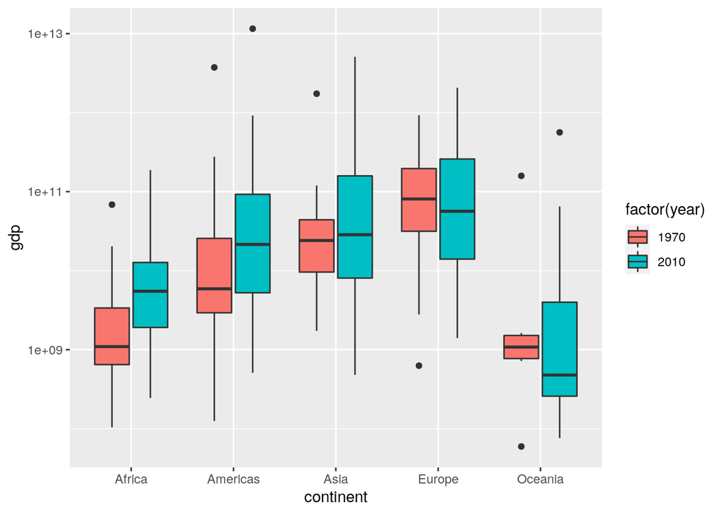

```r
gapminder %>%
  filter(year %in% c(1970, 2010) & !is.na(gdp)) %>%
  ggplot(aes(continent,gdp,fill=factor(year))) +
  scale_y_log10() +
  geom_boxplot()
```

## Exercises

1. Load the **tidyverse** libraries. And load the murders dataset from the **dslabs** package.

2. Make a histogram of the population variable.

3. Instead of a histogram, make a smooth density plot.

4. Make a density plot for region South and region West separately. We can do this using the `filter` and `color` arguments.

5. Assign groups through the `fill` argument instead of `color`. This has the added benefit that it uses colors to distinguish the groups. However, here the second density is drawn over the other. We can make the curves more visible by using alpha blending to add transparency. Set the alpha parameter to 0.2 in the `geom_density` function to make this change.